# Robust covariance estimation for partially observed functional data

Hyunsung Kim

2021-06-24

# Covariance estimation from Lounici (2014)

> Lounici, K. (2014). High-dimensional covariance matrix estimation with missing observations. Bernoulli, 20(3), 1029-1058.

$$\tilde{\Sigma}_n = (\delta^{-1} - \delta^{-2})\text{diag}(\Sigma_n^{(\delta)}) + \delta^{-2}\Sigma_n^{(\delta)}, \tag{1.4}$$
$$\hat{\Sigma}^{\lambda} = \underset{S \in \mathcal{S}_p}{\arg\min} \lVert \tilde{\Sigma}_n - S \rVert_2^2 + \lambda \lVert S \rVert_1 \tag{1.5},$$
where $\lVert A \rVert_2$ is the Frobenius norm and $\lVert A \rVert_1$ is the nuclear norm.

- (1.5) 식은 **Singular Value Thresholding (SVT) algorithm**로 optimize. ([*filling*](https://cran.r-project.org/web/packages/filling/filling.pdf) 패키지의 `fill.SVT()`)

  > Cai, J. F., Candès, E. J., & Shen, Z. (2010). [A singular value thresholding algorithm for matrix completion. SIAM Journal on optimization](https://authors.library.caltech.edu/18606/1/Cai2010p10180Siam_J_Optimiz.pdf), 20(4), 1956-1982.
- $\delta$는 known이라 가정하고 이론이 전개되었으나, simulation에서는 다음과 같이 empirical한 값을 사용
  $$\hat\delta = \frac{\sum_{i=1}^p\sum_{j=1}^p \mathbf{1}_{ \{Y(t_{ij}) \text{ is observed} \} } }{p^2},$$
  wherer $p$ is the dimension of covariance.
- Lounici (2014) paper의 식 (3.8)에서 regularization parameter $\lambda$를 선택하는 방법이 소개되어 있으나, 이는 constant $C$에 depend하며 그냥 충분히 큰 상수라고만 언급되어있음….
  $$\lambda = C \frac{\sqrt{\text{tr}(\tilde\Sigma_n) \lVert \tilde\Sigma_n \rVert_\infty }}{\delta} \sqrt{\frac{\log(2p)}{n}}, \tag{3.8}$$
  where $C>0$ is a large enough constant.

# Non-contaminated case

- Setting은 이전부터 계속 해왔던 Delaigle (2020) setting을 활용
- 여기서 *M-est*는 *M-est(smooth)*를 의미 (covariance에 bivariate smoothing까지 고려한 경우)
- regularization parameter $\lambda$에 따른 completion 형태를 확인
- 2가지 경우 고려
  1. Lounici (2014)
  2. (1.4)에서 $\Sigma_n^{(\delta)}$을 M-est로 바꾼 경우

## Covariance surfaces

### 1. Lounici (2014)

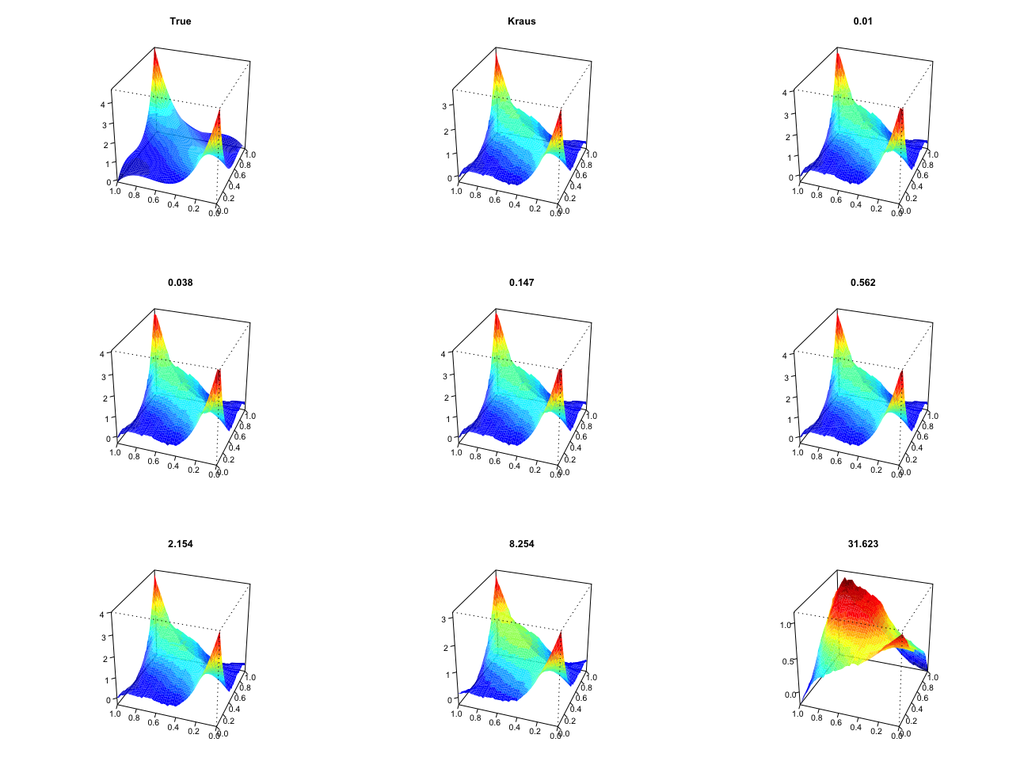

### 2. (1.4)에서 M-est로 바꾼 경우

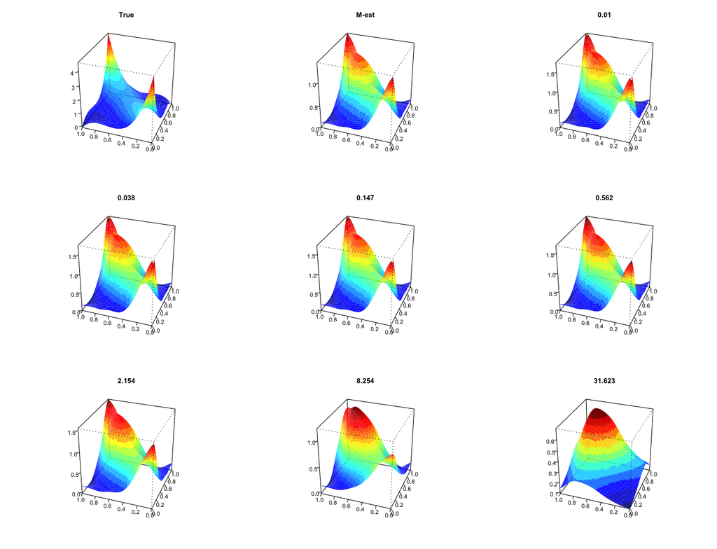

## Completion

### 1. Lounici (2014)

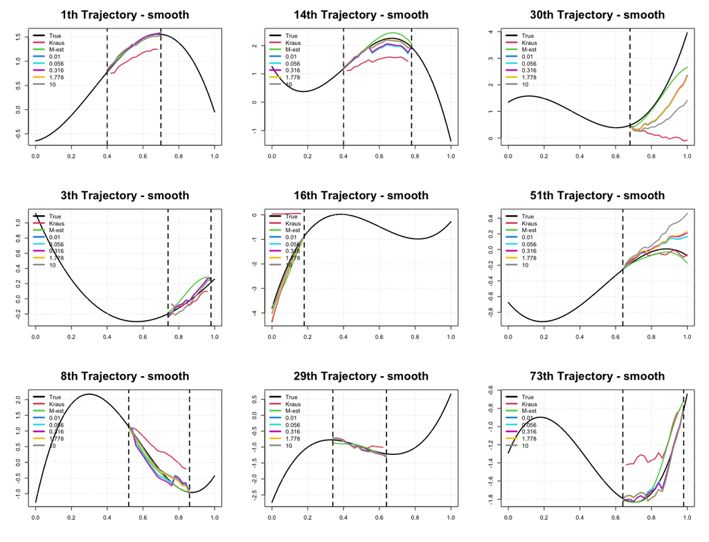

### 2. (1.4)에서 M-est로 바꾼 경우

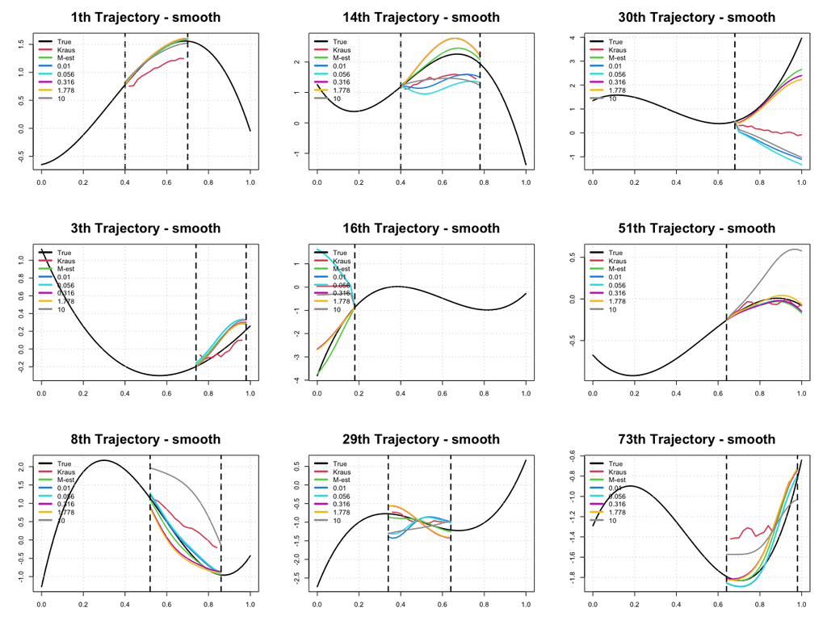

# Contaminated case

## Covariance surfaces

### 1. Lounici (2014)

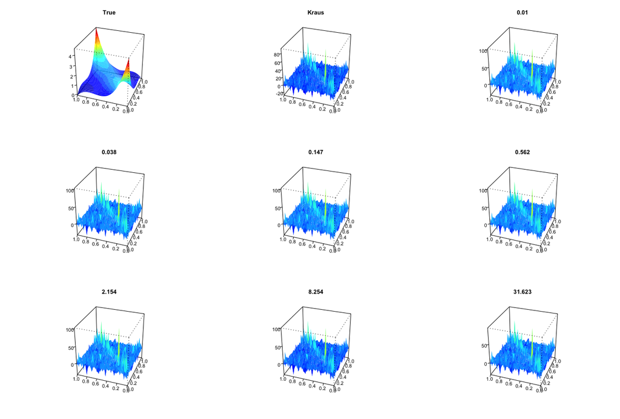

### 2. (1.4)에서 M-est로 바꾼 경우

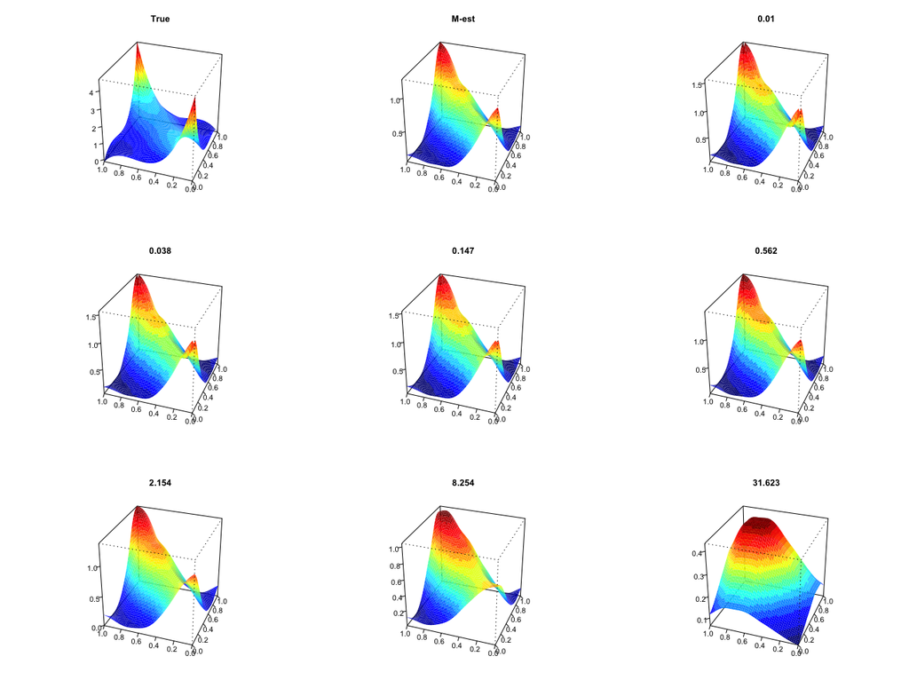

## Completion

### 1. Lounici (2014)

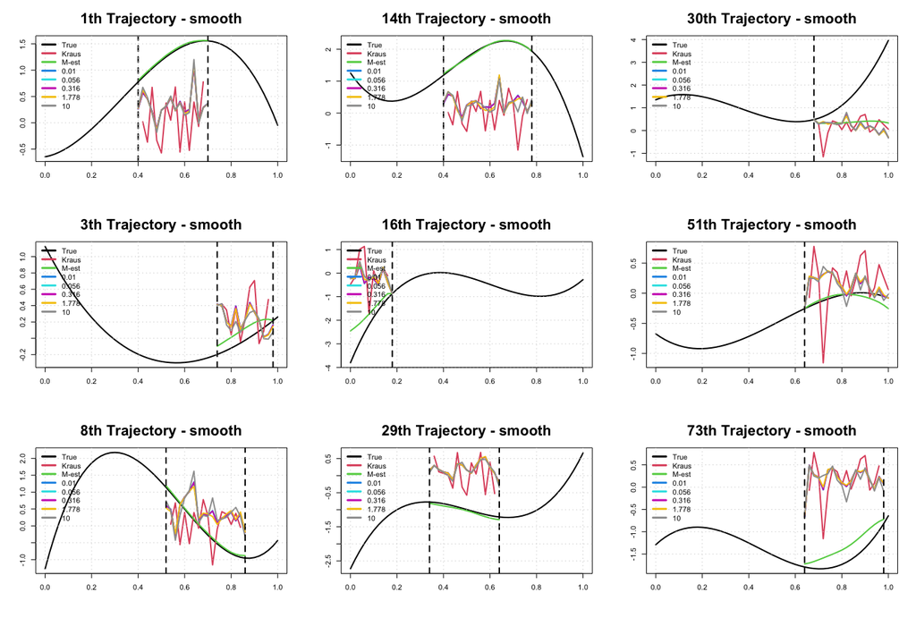

### 2. (1.4)에서 M-est로 바꾼 경우

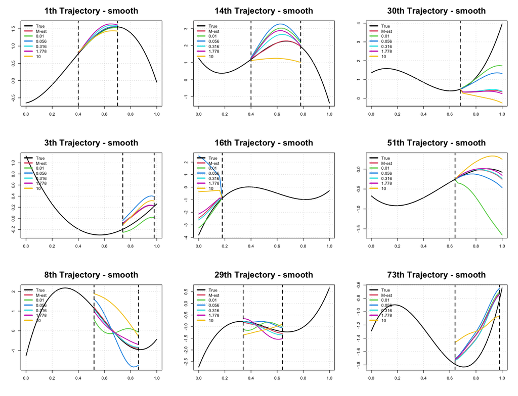